# 2017 Baby weaning

IL, RSU, SU

# Data analysis

Data extracted was tabulated in a google sheet. Then exported as csv file and imported in R (R Core Team (2017). R: A language and environment for statistical computing. R Foundation for Statistical Computing, Vienna, Austria. URL https://www.R-project.org/.)

Risk factors were grouped in reports focused to drink, food or breastfeeding and outcomes were severe early-childhood caries (s-ECC), white spot lesions (WSL) or caries measured in ICDAS>0.

# Dataset

```r
df <- read_csv("2017-weaning.csv")
df <- mutate(df, Groups = paste(Comparison, Outcome))
df <- df %>%
  filter(!str_detect(id, "Un Lam et al")) #avoid Un Lam papers
```

# ANALYSIS

## 1. Breastfeeding and s-ECC

### Selection of papers

| id | Risk factor | Comparison | Outcome | Group A - Protector | Group B - Risk factor | Events in A | Total in A | Events in B | Total in B | Groups |
| --- | --- | --- | --- | --- | --- | --- | --- | --- | --- | --- |
| Peltzer and Mongkolchati, 2015a | Breastfeeding | Breastfeed | S-ECC | Breastfed 1-3 months | Never breastfed | 55 | 155 | 145 | 295 | Breastfeed S-ECC |
| Peres et al 2017a | Breastfeeding | Breastfeed | S-ECC | 13-23 m breastfeeding | >24m breastfeeding | 26 | 129 | 97 | 258 | Breastfeed S-ECC |

```r
meta1
```

[output not shown]

### Bias

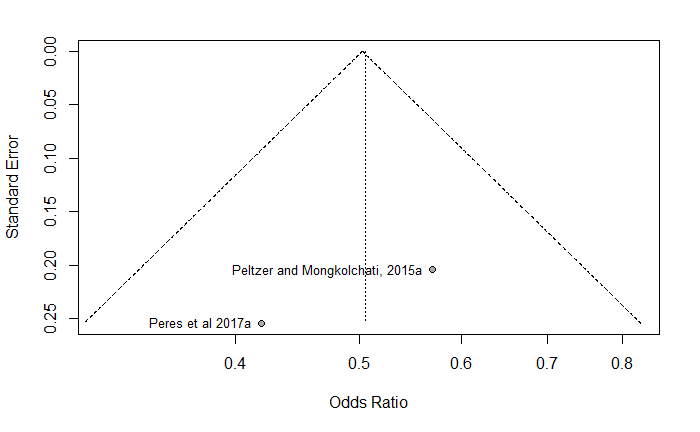

### Heterogeneity

Baujat B, Mahé C, Pignon JP, Hill C (2002), A graphical method for exploring heterogeneity in meta-analyses: Application to a meta-analysis of 65 trials. Statistics in Medicine, 30, 2641–2652.

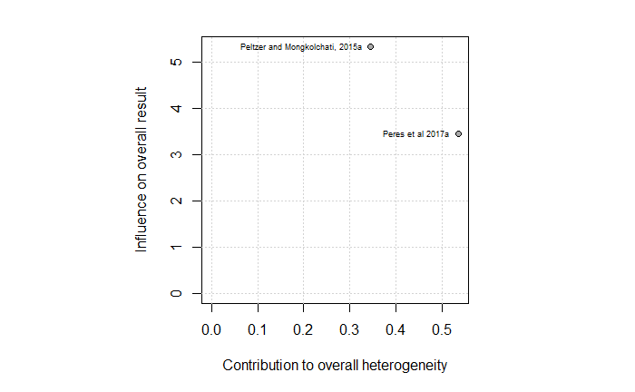

### Meta-analysis

```r
meta1 <- metabin(`Events in A`, `Total in A`,
                 `Events in B`, `Total in B`,
                 data = df_b_ecc,
                 sm="OR",  method.tau = "DL",
                 comb.fixed = FALSE,
                 studlab = id)
```

```r
summary(meta1)
```

```
Number of studies combined: k = 2

                         OR           95%-CI     z  p-value
Random effects model 0.5046 [0.3693; 0.6895] -4.29 < 0.0001

Quantifying heterogeneity:
 tau^2 = 0; H = 1.00; I^2 = 0.0%

Test of heterogeneity:
    Q d.f.  p-value
 0.88    1   0.3480

Details on meta-analytical method:
- Mantel-Haenszel method
- DerSimonian-Laird estimator for tau^2
```

```r
meta1
```

```
                                    OR           95%-CI %W(random)
Peltzer and Mongkolchati, 2015a 0.5690 [0.3812; 0.8492]       60.8
Peres et al 2017a               0.4190 [0.2545; 0.6897]       39.2

Number of studies combined: k = 2

                         OR           95%-CI     z  p-value
Random effects model 0.5046 [0.3693; 0.6895] -4.29 < 0.0001

Quantifying heterogeneity:
 tau^2 = 0; H = 1.00; I^2 = 0.0%

Test of heterogeneity:
    Q d.f.  p-value
 0.88    1   0.3480

Details on meta-analytical method:
- Mantel-Haenszel method
- DerSimonian-Laird estimator for tau^2
```

#### Forest plot

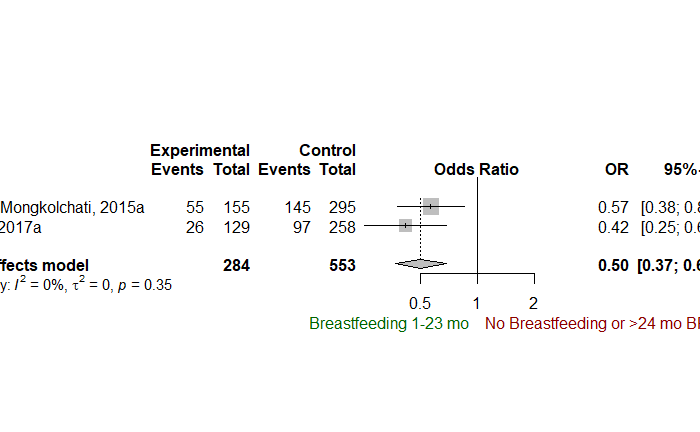

## 2. Sugary drinks and s-ECC

### Selection of papers

| id | Risk factor | Comparison | Outcome | Group A - Protector | Group B - Risk factor | Events in A | Total in A | Events in B | Total in B | Groups |
| --- | --- | --- | --- | --- | --- | --- | --- | --- | --- | --- |
| Peltzer and Mongkolchati, 2015b | Introduction to soft drinks | Drink | S-ECC | Never soft drinks | introduced 6-12 months soft drinks | 113 | 289 | 144 | 299 | Drink S-ECC |
| Peltzer and Mongkolchati, 2015c | Sleeps with bottle at 30 months | Drink | S-ECC | No Sleeps with bottle at 30 months | 1–6 times/week Sleeps with bottle at 30 months | 187 | 454 | 76 | 142 | Drink S-ECC |

### Bias

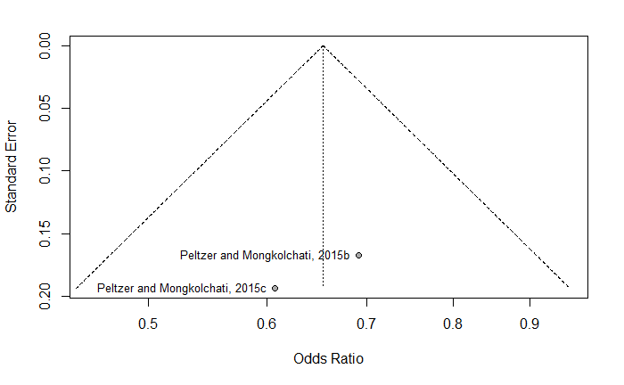

### Heterogeneity

Baujat B, Mahé C, Pignon JP, Hill C (2002), A graphical method for exploring heterogeneity in meta-analyses: Application to a meta-analysis of 65 trials. Statistics in Medicine, 30, 2641–2652.

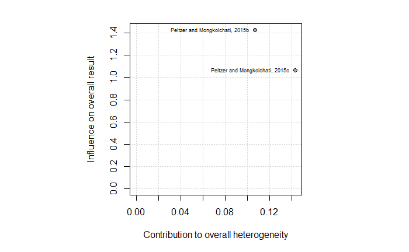

### Meta-analysis

| id | Risk factor | Comparison | Outcome | Group A - Protector | Group B - Risk factor | Events in A | Total in A | Events in B | Total in B | Groups |
| --- | --- | --- | --- | --- | --- | --- | --- | --- | --- | --- |
| Peltzer and Mongkolchati, 2015b | Introduction to soft drinks | Drink | S-ECC | Never soft drinks | introduced 6-12 months soft drinks | 113 | 289 | 144 | 299 | Drink S-ECC |
| Peltzer and Mongkolchati, 2015c | Sleeps with bottle at 30 months | Drink | S-ECC | No Sleeps with bottle at 30 months | 1–6 times/week Sleeps with bottle at 30 months | 187 | 454 | 76 | 142 | Drink S-ECC |

```r
summary(meta1)
```

```
Number of studies combined: k = 2

                         OR           95%-CI     z  p-value
Random effects model 0.6544 [0.5107; 0.8384] -3.35   0.0008

Quantifying heterogeneity:
 tau^2 = 0; H = 1.00; I^2 = 0.0%

Test of heterogeneity:
    Q d.f.  p-value
 0.25    1   0.6172

Details on meta-analytical method:
- Mantel-Haenszel method
- DerSimonian-Laird estimator for tau^2
```

```r
meta1
```

```
                                    OR           95%-CI %W(random)
Peltzer and Mongkolchati, 2015b 0.6911 [0.4981; 0.9589]       57.3
Peltzer and Mongkolchati, 2015c 0.6082 [0.4163; 0.8885]       42.7

Number of studies combined: k = 2

                         OR           95%-CI     z  p-value
Random effects model 0.6544 [0.5107; 0.8384] -3.35   0.0008

Quantifying heterogeneity:
 tau^2 = 0; H = 1.00; I^2 = 0.0%

Test of heterogeneity:
    Q d.f.  p-value
 0.25    1   0.6172

Details on meta-analytical method:
- Mantel-Haenszel method
- DerSimonian-Laird estimator for tau^2
```

#### Forest plot

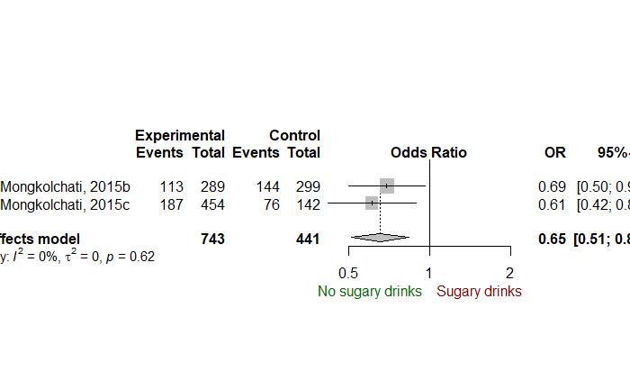

## 3. Food White and spot lesions

### Selection of papers

| id | Risk factor | Comparison | Outcome | Group A - Protector | Group B - Risk factor | Events in A | Total in A | Events in B | Total in B | Groups |
| --- | --- | --- | --- | --- | --- | --- | --- | --- | --- | --- |
| Moimaz et al, 2014b | Cariogenic foods during meals | Food | White spot lesions | No Cariogenic foods during meals | Cariogenic foods during meals | 4 | 9 | 32 | 71 | Food White spot lesions |
| Moimaz et al, 2014c | Cariogenic foods between meals | Food | White spot lesions | No Cariogenic foods between meals | Cariogenic foods between meals | 1 | 2 | 35 | 78 | Food White spot lesions |

### Bias

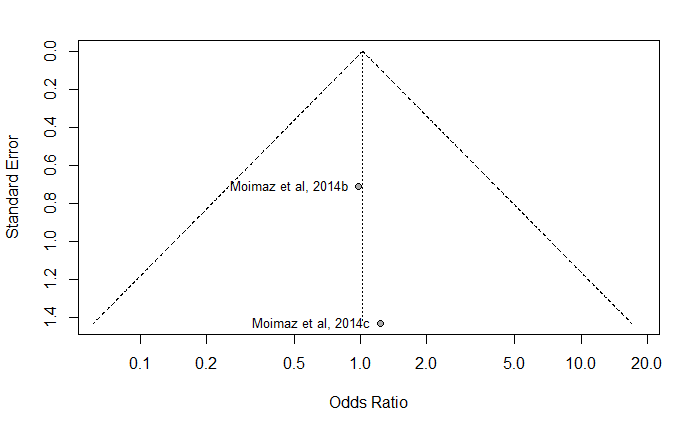

### Heterogeneity

Baujat B, Mahé C, Pignon JP, Hill C (2002), A graphical method for exploring heterogeneity in meta-analyses: Application to a meta-analysis of 65 trials. Statistics in Medicine, 30, 2641–2652.

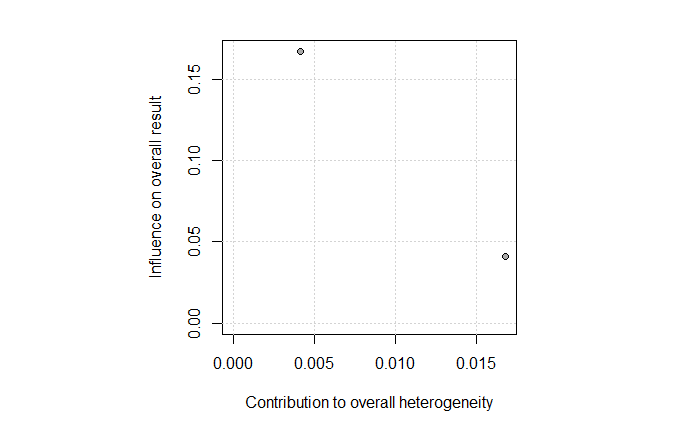

### Meta-analysis

```r
summary(meta1)
```

```
Number of studies combined: k = 2

                         OR           95%-CI    z  p-value
Random effects model 1.0207 [0.2926; 3.5611] 0.03   0.9744

Quantifying heterogeneity:
 tau^2 = 0; H = 1.00; I^2 = 0.0%

Test of heterogeneity:
    Q d.f.  p-value
 0.02    1   0.8851

Details on meta-analytical method:
- Mantel-Haenszel method
- DerSimonian-Laird estimator for tau^2
```

```r
meta1
```

```
                        OR            95%-CI %W(random)
Moimaz et al, 2014b 0.9750 [0.2415;  3.9358]       80.2
Moimaz et al, 2014c 1.2286 [0.0742; 20.3554]       19.8

Number of studies combined: k = 2

                         OR           95%-CI    z  p-value
Random effects model 1.0207 [0.2926; 3.5611] 0.03   0.9744

Quantifying heterogeneity:
 tau^2 = 0; H = 1.00; I^2 = 0.0%

Test of heterogeneity:
    Q d.f.  p-value
 0.02    1   0.8851

Details on meta-analytical method:
- Mantel-Haenszel method
- DerSimonian-Laird estimator for tau^2
```

#### Forest plot

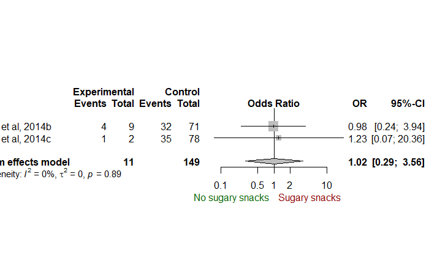

# References

```r
citation(package = "meta")
```

```
  Guido Schwarzer (2007), meta: An R package for meta-analysis, R News, 7(3),
  40-45.

A BibTeX entry for LaTeX users is

  @Article{,
    title = {meta: {A}n {R} package for meta-analysis},
    author = {Guido Schwarzer},
    journal = {R News},
    year = {2007},
    volume = {7},
    number = {3},
    pages = {40--45},
  }

URL https://cran.r-project.org/doc/Rnews/Rnews_2007-3.pdf
```